# Introduction

Steam (https://store.steampowered.com/) is the largest digital distribution platform for PC games, hosting thousands of games at all prices. In this project, we work with a large scraped dataset of Steam games (up to 2025) to study two linked phenomena: (i) which patterns are common among successful indie games, and (ii) how game genres evolve over time (lifecycle).

## Explanation of the Dataset

The core data source is the *Steam Games Dataset* from Kaggle https://www.kaggle.com/datasets/artermiloff/steam-games-dataset/data, containing scraped information about games published on Steam up to 2025 (metadata, tags/genres, estimated owners, etc.). We complemented and validated certain games using SteamDB (https://steamdb.info/), which provides additional public information and estimations.

The dataset contains a total of **94,948 observations** and **47 variables**. It includes a mix of numeric values (price, reviews, owner estimates, playtime, etc.) and textual or categorical descriptors (genres, tags, categories, developers, etc.).

- **appid**: Unique identifier of the game on Steam. *(numeric)*
- **name**: Name of the game. *(text)*
- **release_date**: Date when the game was released. *(time)*
- **required_age**: Minimum age required to play the game. *(numeric)*
- **price**: Game price; 0 indicates Free-to-Play. *(numeric)*
- **dlc_count**: Number of downloadable contents (DLCs). *(numeric)*
- **support_url**: URL to the game’s support page. *(text)*
- **windows, mac, linux**: Supported platforms. *(categorical)*
- **metacritic_score**: Metacritic score based on professional reviews. *(numeric)*
- **achievements**: Number of achievements. *(numeric)*
- **recommendations**: Number of user recommendations. *(numeric)*
- **supported_languages**: Languages supported by the game. *(text)*
- **packages**: Available packages and subpackages for the game. *(text)*
- **developers**: Developers associated with the game. *(text)*
- **publishers**: Publishers associated with the game. *(text)*
- **categories**: Steam categories of the game. *(text)*
- **genres**: Steam genres of the game. *(text)*
- **positive**: Number of positive user reviews. *(numeric)*
- **negative**: Number of negative user reviews. *(numeric)*
- **estimated_owners**: Estimated number of owners. *(numeric)*
- **average_playtime_forever**: Average playtime since March 2009 (minutes). *(numeric)*
- **average_playtime_2weeks**: Average playtime in the last two weeks (minutes). *(numeric)*
- **median_playtime_forever**: Median playtime since March 2009 (minutes). *(numeric)*
- **median_playtime_2weeks**: Median playtime in the last two weeks (minutes).* (numeric)*
- **peak_ccu**: Peak concurrent users on the day before scraping. *(numeric)*
- **tags**: List of user-defined tags with names and keys. *(text)*
- **pct_pos_total**: Percentage of positive reviews. *(numeric)*
- **num_reviews_total**: Total number of reviews. *(numeric)*

## Objectives

The objective of this project is to analyse the Steam video game ecosystem with a focus on indie titles, using data mining and exploratory data analysis techniques to extract interpretable and actionable insights.

1. **Prepare and structure the Steam dataset for analysis** by identifying relevant variables, handling missing, duplicated, and inconsistent values, and formatting raw attributes for data mining techniques.
2. **Analyze long-term genre dynamics on Steam** by studying how grouped game genres evolve over time in terms of market share and player engagement.
3. **Identify common patterns among successful indie games** by constructing an operational proxy for success using clustering over engagement and market signals, and then mining frequent genre, mechanic, and characteristic combinations within the successful subset.
4. **Evaluate the role of pricing and visibility** by studying the relationship between price, estimated owners, and engagement indicators using multivariate regression.
5. **Study the influence of successful indie games on genre and tag evolution** through targeted case studies that analyze changes in tag usage before and after the release of highly influential titles.

The goal is not to define rules for success, but to discover recurring patterns and associations that help better understand the indie game market and support game design decisions.

# Procesing de data

General look of the dataset

```r
summary(steam)
```

```
##      appid             name           release_date        required_age
##  Min.   :     20   Length:94948       Length:94948       Min.   :-1.0000
##  1st Qu.: 887338   Class :character   Class :character   1st Qu.: 0.0000
##  Median :1591145   Mode  :character   Mode  :character   Median : 0.0000
##  Mean   :1707531                                         Mean   : 0.1783
##  3rd Qu.:2491703                                         3rd Qu.: 0.0000
##  Max.   :3570420                                         Max.   :21.0000
##
##      price            dlc_count         detailed_description about_the_game
##  Min.   :   0.000   Min.   :   0.0000   Length:94948         Length:94948
##  1st Qu.:   0.990   1st Qu.:   0.0000   Class :character     Class :character
##  Median :   3.990   Median :   0.0000   Mode  :character     Mode  :character
##  Mean   :   6.911   Mean   :   0.5632
##  3rd Qu.:   9.990   3rd Qu.:   0.0000
##  Max.   : 999.980   Max.   :3427.0000
##
##  short_description    reviews          header_image         website
##  Length:94948       Length:94948       Length:94948       Length:94948
##  Class :character   Class :character   Class :character   Class :character
##  Mode  :character   Mode  :character   Mode  :character   Mode  :character
##
##
##
##
##  support_url        support_email        windows              mac
##  Length:94948       Length:94948       Length:94948       Length:94948
##  Class :character   Class :character   Class :character   Class :character
##  Mode  :character   Mode  :character   Mode  :character   Mode  :character
##
##
##
##
##     linux           metacritic_score metacritic_url      achievements
##  Length:94948       Min.   : 0.000   Length:94948       Min.   :   0.00
##  Class :character   1st Qu.: 0.000   Class :character   1st Qu.:   0.00
##  Mode  :character   Median : 0.000   Mode  :character   Median :   2.00
##                     Mean   : 2.764                      Mean   :  19.54
##                     3rd Qu.: 0.000                      3rd Qu.:  19.00
##                     Max.   :97.000                      Max.   :9821.00
##
```

[output cut: 49 more lines]

```
##  Length:94948       Min.   : -1.00   Min.   :     -1   Min.   : -1.000
##  Class :character   1st Qu.: -1.00   1st Qu.:     -1   1st Qu.: -1.000
##  Mode  :character   Median : 58.00   Median :     15   Median : -1.000
##                     Mean   : 44.63   Mean   :   1448   Mean   :  5.328
##                     3rd Qu.: 84.00   3rd Qu.:     80   3rd Qu.: -1.000
##                     Max.   :100.00   Max.   :8632939   Max.   :100.000
##
##  num_reviews_recent
##  Min.   :   -1.00
##  1st Qu.:   -1.00
##  Median :   -1.00
##  Mean   :   16.88
##  3rd Qu.:   -1.00
##  Max.   :96473.00
##
```

## Handling of NA values

The attributes with missing values are:

```r
na_counts <- steam %>% summarise_all(~ sum(is.na(.)))

print(na_counts)
```

```
##   appid name release_date required_age price dlc_count detailed_description
## 1     0    0            0            0     0         0                    0
##   about_the_game short_description reviews header_image website support_url
## 1              0                 0       0            0       0           0
##   support_email windows mac linux metacritic_score metacritic_url achievements
## 1             0       0   0     0                0              0            0
##   recommendations notes supported_languages full_audio_languages packages
## 1               0     0                   0                    0        0
##   developers publishers categories genres screenshots movies user_score
## 1          0          0          0      0           0      0          0
##   score_rank positive negative estimated_owners average_playtime_forever
## 1      94909        0        0                0                        0
##   average_playtime_2weeks median_playtime_forever median_playtime_2weeks
## 1                       0                       0                      0
##   discount peak_ccu tags pct_pos_total num_reviews_total pct_pos_recent
## 1        0        0    0             0                 0              0
##   num_reviews_recent
## 1                  0
```

The columns with missing values are as follows:

LOs juegos con número de reseñas = -1 creemos que son porque el scrappear ha fallado durante su ejecución. Si vamos a trabajar con las reseñas podríamos decir en la presentación que vamos a probar de volver a intentar scrappear la información

```
## tibble [88,982 × 31] (S3: tbl_df/tbl/data.frame)
##  $ appid                   : int [1:88982] 2556940 449940 1287250 866510 870990 439260 388390 2243560 1908870 3165610 ...
##  $ name                    : chr [1:88982] "! Shakabula *" "! That Bastard Is Trying To Steal Our Gold !" "! Wild Russia !" "!AnyWay!" ...
##  $ release_date            : Date[1:88982], format: "2023-10-13" "2016-03-03" ...
##  $ required_age            : int [1:88982] 0 0 0 0 0 0 0 0 0 0 ...
##  $ price                   : num [1:88982] 14.99 2.99 19.99 1.99 0.99 ...
##  $ dlc_count               : int [1:88982] 0 0 0 39 0 0 0 1 3 0 ...
##  $ windows                 : chr [1:88982] "True" "True" "True" "True" ...
##  $ mac                     : chr [1:88982] "False" "False" "False" "False" ...
##  $ linux                   : chr [1:88982] "False" "True" "False" "False" ...
##  $ metacritic_score        : int [1:88982] 0 0 0 0 0 0 0 0 0 0 ...
##  $ achievements            : int [1:88982] 0 0 9 4997 2021 0 0 19 13 5 ...
##  $ recommendations         : int [1:88982] 0 0 0 495 0 0 0 108 0 0 ...
##  $ supported_languages     : chr [1:88982] "['English']" "['English']" "['English', 'Simplified Chinese', 'Russian']" "['English', 'Russian', 'French', 'Italian', 'German', 'Polish', 'Ukrainian', 'Swedish', 'Simplified Chinese', '"| __truncated__ ...
##  $ packages                : chr [1:88982] "[{'title': 'Buy ! Shakabula *', 'description': '', 'subs': [{'text': '! Shakabula * - $14.99', 'description': '"| __truncated__ "[{'title': 'Buy ! That Bastard Is Trying To Steal Our Gold !', 'description': '', 'subs': [{'text': '! That Bas"| __truncate…
```

[output cut: 17 more lines]

```
##      appid             name            release_date         required_age
##  Min.   :     20   Length:88982       Min.   :1997-06-30   Min.   :-1.0000
##  1st Qu.: 852783   Class :character   1st Qu.:2018-12-05   1st Qu.: 0.0000
##  Median :1522535   Mode  :character   Median :2021-10-29   Median : 0.0000
##  Mean   :1655079                      Mean   :2021-04-04   Mean   : 0.1826
##  3rd Qu.:2429338                      3rd Qu.:2023-12-14   3rd Qu.: 0.0000
##  Max.   :3542350                      Max.   :2025-03-10   Max.   :21.0000
##      price            dlc_count           windows              mac
##  Min.   :   0.000   Min.   :   0.0000   Length:88982       Length:88982
##  1st Qu.:   0.990   1st Qu.:   0.0000   Class :character   Class :character
##  Median :   4.990   Median :   0.0000   Mode  :character   Mode  :character
##  Mean   :   7.349   Mean   :   0.5957
##  3rd Qu.:   9.990   3rd Qu.:   0.0000
##  Max.   : 999.980   Max.   :3427.0000
##     linux           metacritic_score  achievements     recommendations
##  Length:88982       Min.   : 0.00    Min.   :   0.00   Min.   :      0
##  Class :character   1st Qu.: 0.00    1st Qu.:   0.00   1st Qu.:      0
##  Mode  :character   Median : 0.00    Median :   5.00   Median :      0
##                     Mean   : 2.91    Mean   :  20.67   Mean   :   1013
##                     3rd Qu.: 0.00    3rd Qu.:  20.00   3rd Qu.:      0
##                     Max.   :97.00    Max.   :9821.00   Max.   :4401572
##  supported_languages   packages          developers         publishers
##  Length:88982        Length:88982       Length:88982       Length:88982
##  Class :character    Class :character   Class :character   Class :character
##  Mode  :character    Mode  :character   Mode  :character   Mode  :character
##
##
##
##   categories           genres             positive          negative
##  Length:88982       Length:88982       Min.   :      0   Min.   :      0.0
##  Class :character   Class :character   1st Qu.:      1   1st Qu.:      0.0
##  Mode  :character   Mode  :character   Median :     10   Median :      2.0
##                                        Mean   :   1267   Mean   :    208.3
##                                        3rd Qu.:     59   3rd Qu.:     17.0
##                                        Max.   :7480813   Max.   :1135108.0
##  estimated_owners   average_playtime_forever average_playtime_2weeks
##  Length:88982       Min.   :      0.0        Min.   :    0.000
##  Class :character   1st Qu.:      0.0        1st Qu.:    0.000
##  Mode  :character   Median :      0.0        Median :    0.000
##                     Mean   :    115.6        Mean   :    4.998
```

[output cut: 8 more lines]

```
##  Max.   :1462997.0       Max.   :18568.000      Max.   :1.212e+06
##      tags           pct_pos_total    num_reviews_total estimated_owners_min
##  Length:88982       Min.   : -1.00   Min.   :     -1   Min.   :        0
##  Class :character   1st Qu.: -1.00   1st Qu.:     -1   1st Qu.:        0
##  Mode  :character   Median : 60.00   Median :     15   Median :        0
##                     Mean   : 45.39   Mean   :   1320   Mean   :    59038
##                     3rd Qu.: 84.00   3rd Qu.:     81   3rd Qu.:        0
##                     Max.   :100.00   Max.   :8632939   Max.   :200000000
##  estimated_owners_max
##  Min.   :        0
##  1st Qu.:    20000
##  Median :    20000
##  Mean   :   143056
##  3rd Qu.:    20000
##  Max.   :500000000
```

# Exploratory Data Analysis

Now we going to explore the market share of each genre and how it evolves through time, and the playtime of each genre trying to see which are the genres with more hardcore players.

Firstly for having a objective view if the genre have truly grown we going to mesure the market share of each genre of each year. The advantage of using this is that the grown of each year is relative to the total grown of the game industry, if we use the raw game numbers we cannot difference if the game have actually grown or it’s because the general game market have a growing tendency.

$$\text{Market Share} = \frac{\text{Genre Games}}{\text{Total Games}}$$

Now let’s define some metrics to determine the performance and behavior of the genres. The net growth is the difference between the final market share and the initial market share, with this metric we can see which genre have grown the most. And another metric is the volatility wihch is the sum of all the absolute value of the difference between the previous and current year.

$$\text{Net Growth} = \text{Market Share}_\text{final} - \text{Market
Share}_{initial}$$

$$\text{Volatility} = \sum |\Delta \text{Market Share}|$$

```
## # A tibble: 14 × 3
##    Genre       Total_Volatility Net_Growth
##    <chr>                  <dbl>      <dbl>
##  1 action                  54.0     10.8
##  2 casual                  43.6     15.8
##  3 platformer              41.4      8.51
##  4 tabletop                36.6    -12.3
##  5 strategy                28.8     -8.60
##  6 shooter                 27.6     -0.703
##  7 RPG                     23.7      9.25
##  8 fighting                19.3      2.04
##  9 simulation              18.1      2.60
## 10 horror                  15.4      5.90
## 11 sport                   13.8      0.224
## 12 walking_sim             13.7      2.64
## 13 roguelike               13.2      8.59
## 14 music                   10.3     -2.58
```

[figure not shown]

We can see a the rise of the casual genre, this can be cause due to playing video game is every time more popular and not only for few nerd thing. And video game is an social activity media between the young people who use chat platforms like Discord and play together, this can explain why the rise of casual games like “Fall Guys”, “Lethal Company”, “R.E.P.O.”, “PEAK”, “MIMESIS”, … And the genres like action, RPG, roguelike and platformer are very typical genres of indie games, and indie games occupies the majority of the game publication so it make sense that they are on the top. One interest things is the rise of the horror genre which looks like a niche genre, but I think the rise of the horror game is thanks to the stream culture, because streamer playing horror games is very entertaining for the public and this make those games popular.

On the other hand, the bottom 3 are music, strategy and tabletop which are niche genres. One interest genre is shooter which have a negative grown, but there’s a lot of shooter players and it’s one of the most viewed category of Twitch. I think the cause of this phenomenon is that shooter game are very monopolized, because the main category of shooter is the competitive shooter like “CSGO (CS2)”, “VALORANT”, “APEX”, “FORNITE”, “PUBG”, “R6”, … Because the nature to compete the players tends to play the same games to have a metric to show their skill. So even that the shooter is a big genre with a big community, it actually doesn’t grow in term of Market Share because in this genre they have few games but very polished.

Visualization the grouth of the genre

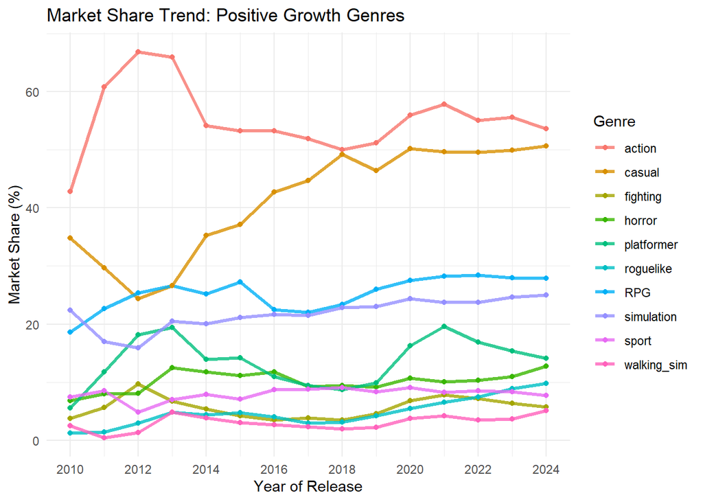

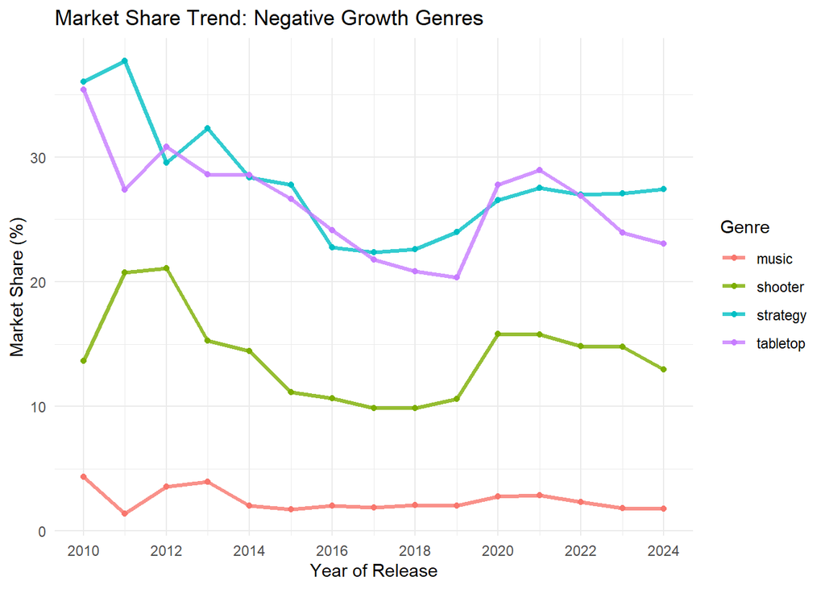

We can see reflected the graph the most volatile genre like action which in 2012 peaked, casual which is in constant rising, platformer which have a peak in 2013 then it went down and later in 2021 it peaked again. For table top it have been decreasing except between 2020 and 2022 it recovered. And finally the strategy game seems to be recoverying since 2016 until 2024 it looks like to stabilize.

In conclusion, the game genre market is very hard to predict because it’s mainly influeced by the trend of the people. A very niche genre can become very trendy because some famous have played it, or in that genre has come out a very good game and that game heavily influence back to the genre, like Holow Knogh to metroidvania genre, The binding of Isaac to the roguelike genre, … For this specific question we have a specific section to answer this.

Now let’s see how behave the playtime of the players of each genre group, we going to see the mean playtime to have an idea of which genre have more time spended, and median playtime to have a view of a typical player playtime.

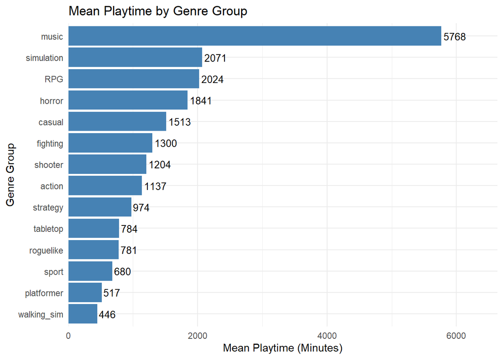

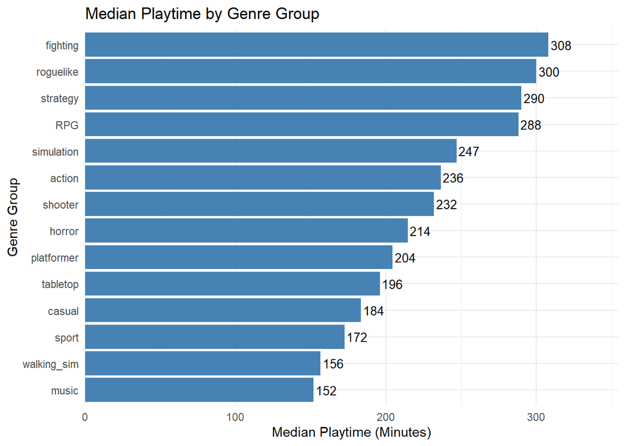

We can see the mean playtime is a lot higher than the median playtime, this is sign that the playtime distribution is skewed. Because of the hardcore player that spend a lot more time than the rest of the player which make the mean higher.

Now it’s interesting to see which genre have the more hardcore players, we can use the ratio between the mean about the median to calculate the skewness ratio of the genre. If the skewness ratio > 1 means that there’s few players that plays a lot making the mean higher.

$$\text{Skewness Ratio} = \frac{\text{Mean}}{\text{Median}}$$
Visualization

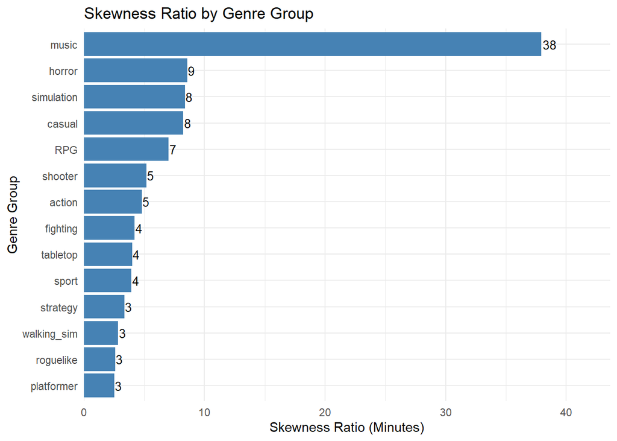

# Commonalities among successful indie games

Indie game development is high-risk: budgets are limited, marketing reach is uncertain, and audience discovery can be unpredictable. This section explores commonalities across successful indie games, with two practical goals: * **Understand market audience:** identify what combinations of genres/mechanics tend to co-occur among games that reach larger audiences. * **Reduce risk for game-making:** extract patterns that can guide design decisions without prescribing a single “correct” formula.

We focus on four questions: * **Does genre matter?** * **Do mechanics matter (especially in combination with genre)?** * **Do game characteristics matter (e.g., camera, player modes, VR)?** * **Does pricing matter (relationship with owners)?**

## Selecting indie games

Steam has done the hard work for us by including “Indie” as a genre/tag (and related tags such as “Crowdfunded” / “Kickstarter”). Given that these tags have been assigned by users world-wide, we can agree on these tags representing widely-considered indie games. We filter the dataset to games containing any of these signals in Genres, Tags or Categories.

## Determining “successful” indie games

Determining “successful” indie games

“Success” is not directly labeled in the dataset, so we build an operational proxy based on market and engagement signals. The main goal of this step is to isolate a subset of indie games that consistently perform better than the rest, so that later sections (association rules and plots) focus on patterns that appear among higher-impact titles.

### Clustering approach

We cluster indie games using a set of numeric variables that capture outcomes and engagement (e.g., recommendations, reviews, playtime, peak CCU, owners/revenue estimates, price, and platform availability). Before fixing the final configuration, we experimented with multiple numbers of clusters: * **2 clusters** (attempting to represent successful vs not successful) * **3 clusters** (attempting to represent massively successful, successful and not successful) * **4 clusters** * **5 clusters** * **10 clusters**

The best segmentation for interpretability and separation was obtained with 3 clusters.

In our dataset, representative examples of these mid/high clusters included games such as Deceit, Graveyard Keeper, Unturned (mid-tier), and Stardew Valley, Subnautica, Terraria (top-tier). These examples illustrate how the clustering captures meaningful outcome tiers rather than arbitrary partitions.

We implement the final clustering using k-means with k = 3 on standardized variables.

Using this proxy, 37,500 games are labeled successful (57.8% of indie games).

### Validation: do clusters separate meaningfully?

Because clustering is unsupervised, we validate quality using a simple but practical hypothesis: *If the most discriminant variable is unable to separate the clusters, then the clustering is likely not meaningful.* We therefore compute the variable that best differentiates the clusters (highest ANOVA F-statistic) and verify that it produces a clear separation across groups.

In our case, the most discriminant variable is pct_pos_total and it produces a clean ordering between the three clusters, which supports using this partition in the rest of the report.

As an additional sanity check, we compute a global silhouette score on a random sample of games in the standardized feature space. Silhouette values closer to 1 indicate well-separated clusters, values near 0 indicate overlap, and negative values suggest poor assignments.

The average silhouette score on the sample is 0.414.

### Cluster interpretation

The figure below summarizes the mean and median values of the discriminant variable (pct_pos_total) across clusters, alongside the number of games per tier.

In our run, the discriminant variable is pct_pos_total, which acts as a strong quality/visibility signal: the unsuccessful long-tail cluster concentrates near the lowest values, while the two top-tier cluster achieves the highest values, separating games with limited traction from games with stable success.

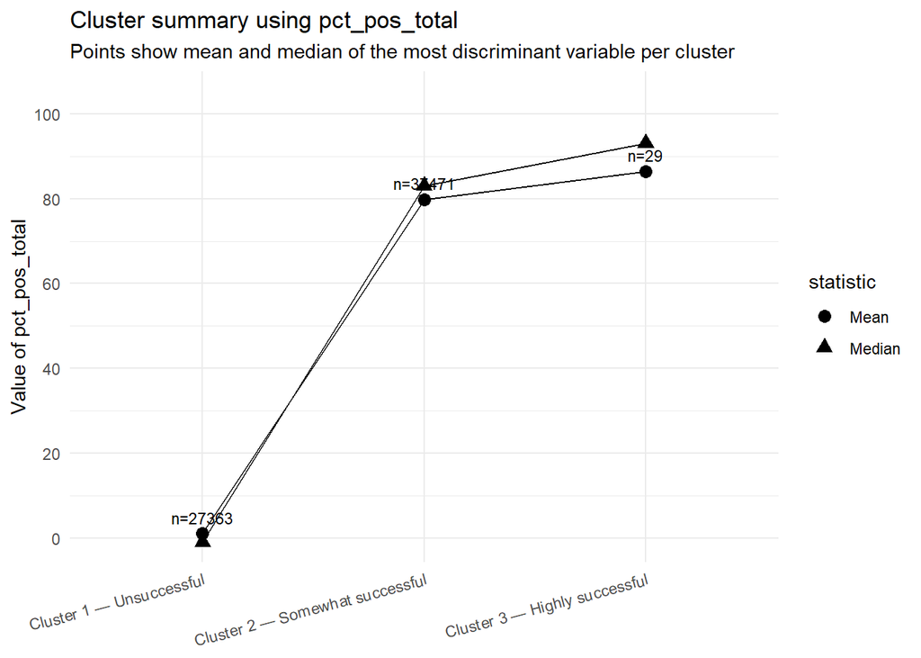

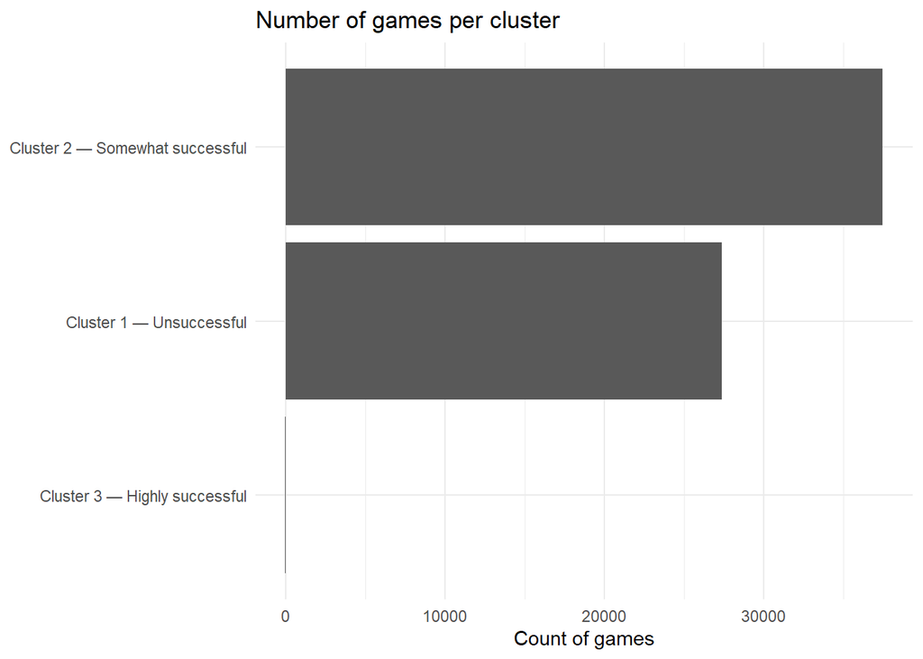

Since the clusters are interpretable and separable (both visually and by the discriminant variable test), we use them to define a successful subset and proceed with pattern mining in the next sections.

## Genre study

Steam genre labels are sometimes inconsistent, so we use a grouped genre taxonomy created for this project (e.g., action, RPG, strategy, platformer, etc.). Each successful game is mapped into one or more of these grouped genres using its Genres/Tags/Categories. The Genres have been described in a previous section of the document.

Before adopting this approach, we initially attempted to mine association rules directly predicting success, by fixing the right-hand side of the rules to `successful = TRUE`.

However, this produced obscure and highly specific combinations with limited generality: many rules were driven by niche tag mixes or small subsets of games, and they did not reflect the kinds of genre patterns seen in widely recognized successful indie titles.

For that reason, we switched to a more interpretable strategy: First filter the dataset to successful indie games, and then mine frequent itemsets (genre combinations) with sufficient support inside this subset.

This approach still answers our question: *Amongng successful games, what genre combinations are most common?*

### Most common genre combinations (frequent itemsets)

The table below lists the most frequent genre combinations among successful games (support = proportion of successful games containing that combination).

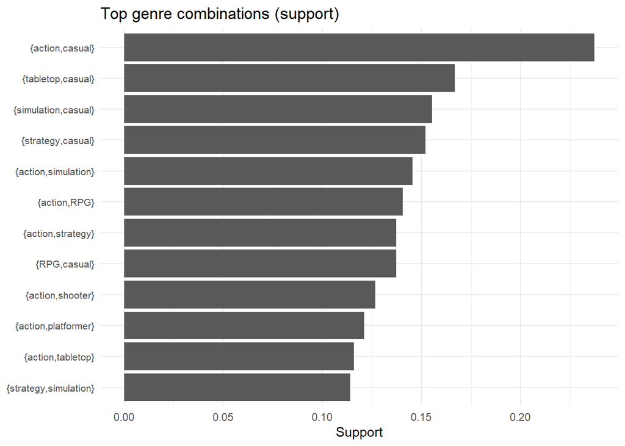

### Genre prevalence

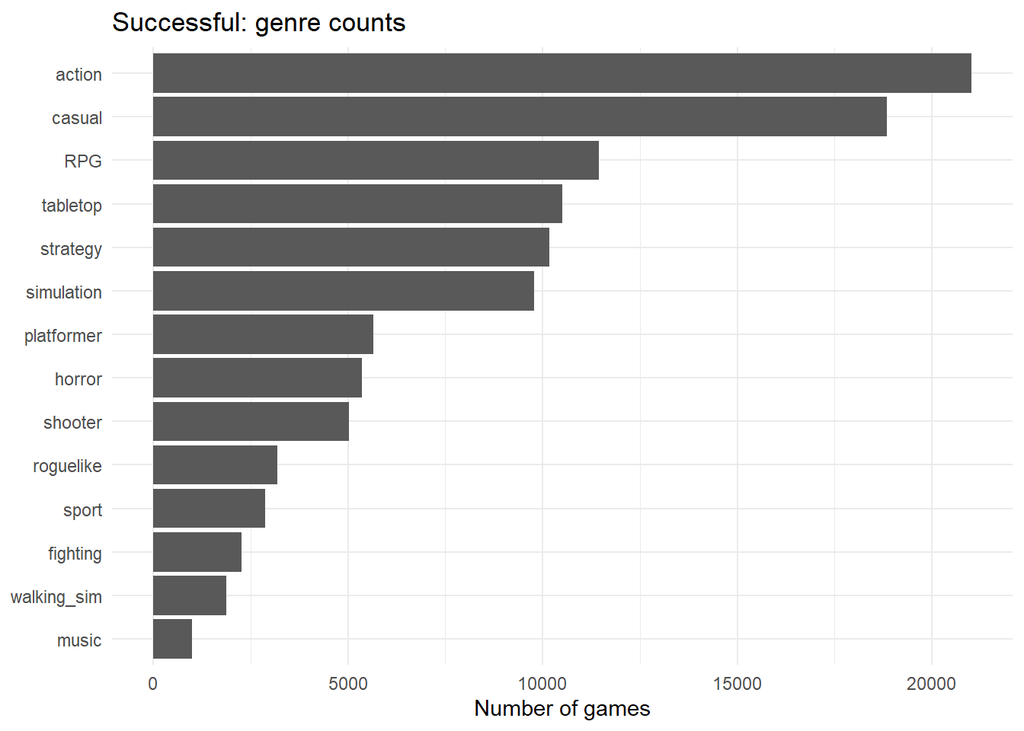

### Conclussions from genres

The grouped genre counts show a highly concentrated distribution: successful indie games most frequently fall under action and casual, followed by a second tier including RPG, tabletop/puzzle, strategy, and simulation. This suggests that, within the successful segment, many games belong to genres that are either broad and audience-friendly (action/casual), or built around deep progression and replayability (RPG/strategy/simulation/tabletop).

Looking at frequent genre combinations (Eclat), the strongest result is the pairing {action, casual}, which appears in roughly one quarter of successful games. More generally, casual acts as a “bridge” genre: it appears in many of the top combinations (e.g., tabletop + casual, simulation + casual, strategy + casual, and RPG + casual). This indicates that many successful indie games mix a core genre identity with accessible design traits (short sessions or low entry difficulty).

The second major pattern is that action combines well with several popular genres: action + RPG, action + simulation, action + strategy, action + shooter, and action + platformer all appear as frequent itemsets. This highlights a typical indie design strategy: start from a strong core action loop and enrich it with complementary systems such as progression (RPG), management (simulation/strategy), or movement challenges (platformer).

## Mechanics study

Mechanics are stored as list of tags (e.g., resource_management, procedural, narrative, card/deckbuilding, etc.) in the steam dataset so they are first one-hot encoded in a binary manner so the apriori algorithm can be executed over them. Instead of only asking “which mechanics are common?”, we also ask: *Given a genre combination, which mechanics are most strongly associated with it?*

We mine association rules of the form: * LHS (antecedent): genre group(s) * RHS (consequent): mechanic group

Rules are ranked by lift to highlight mechanics that occur more often than expected within a genre context. The support is set to `0.01` and confidence to `0.3`. Higher values fail to find interesting relationships in the data.

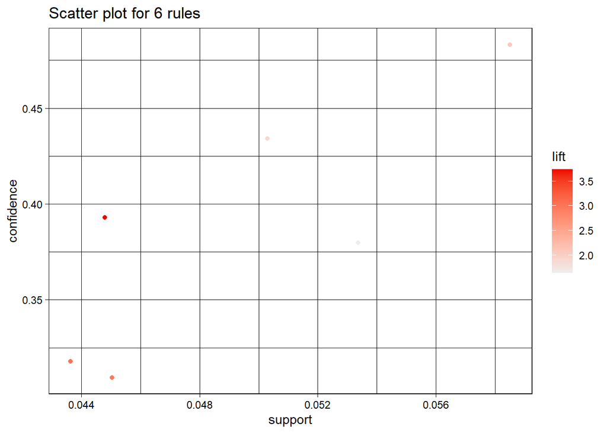

Top genre->mechanic rules among successful indie games (ranked by lift)

| Rule (Genres -> Mechanic) | Support | Confidence | Lift |
| --- | --- | --- | --- |
| {simulation,strategy} => {resource_management} | 0.045 | 0.393 | 3.746 |
| {action,strategy} => {resource_management} | 0.044 | 0.318 | 3.029 |
| {action,simulation} => {resource_management} | 0.045 | 0.310 | 2.950 |
| {action,platformer} => {exploration} | 0.059 | 0.483 | 2.088 |
| {action,tabletop} => {exploration} | 0.050 | 0.434 | 1.876 |
| {action,RPG} => {exploration} | 0.053 | 0.380 | 1.641 |

### Conclussions from genres and mechanic rules

A first clear pattern is the strength of resource management inside strategy/simulation hybrids. The rule {simulation, strategy} -> {resource_management} has the highest lift (around 3.75), meaning that management-oriented mechanics are several times more likely than expected when a game sits at the intersection of these genres. Similar high-lift rules also appear for {action, strategy} and {action, simulation}, suggesting that successful hybrids often combine an action layer with systems such as crafting, automation, building, or economy loops.

A second pattern is that exploration frequently complements action-driven genres. Rules such as {action, platformer} -> {exploration}, {action, tabletop} -> {exploration}, and {action, RPG} -> {exploration} show relatively high confidence, indicating that when successful games blend action with movement/progression, they often reinforce the experience through discovery loops (new areas, loot, dungeons, collectables, or open-ended progression paths).

Overall, the results support a practical conclusion: successful indie games often rely on a core genre identity and then amplify engagement through a matching mechanic; management systems for strategy/simulation hybrids, and exploration loops for action-driven combinations. These associations do not prove causality, but they highlight combinations that repeatedly co-occur among successful titles and can reduce design risk by aligning with common audience expectations.

## Game characteristics study

Characteristics are captured from Steam categories/tags that describe presentation and play modes (e.g., 2D/3D, first-person/third-person, singleplayer/co-op, VR). We mine frequent characteristic combinations using Eclat.

### Top characteristic combinations

Top characteristic combinations among successful indie games

|  | Characteristic combination | Support |
| --- | --- | --- |
| 7 | {Co-op,PvP} | 0.0529 |
| 5 | {Massively Multiplayer,PvP} | 0.0165 |
| 6 | {Massively Multiplayer,Co-op} | 0.0117 |
| 4 | {Massively Multiplayer,Co-op,PvP} | 0.0092 |
| 2 | {VR Only,PvP} | 0.0055 |
| 3 | {VR Only,Co-op} | 0.0044 |
| 1 | {VR Only,Co-op,PvP} | 0.0026 |

### Conclusions from characteristics

The most frequent characteristic combinations in the successful subset are primarily multiplayer-focused, especially the pairing {Co-op, PvP} (support ~ 0.053). This suggests that, among successful indie games that include multiplayer features, a common design choice is to combine collaboration and competition within the same title.

We also observe VR Only appearing in the top combinations but with low support, suggesting that VR-exclusive successful games exist but represent a niche segment compared with traditional PC titles. A plausible explanation is that the VR market offers fewer alternatives overall, so the relatively small number of VR-only titles can capture a larger share of VR players and reach the engagement thresholds needed to be labeled as successful in our proxy, which makes VR-only features show up among the top itemsets.

Overall, characteristics appear to matter mainly as experience modifiers: multiplayer modes (co-op/PvP) are recurring patterns among successful games, while more specialized formats (like VR-only) are less common.

##Pricing and owners Finally, we explore whether price is related to estimated owners. We initially attempted to approach this with a simple scatter plot which ended up hard to interpret due to heavy overlap and the long-tail nature of owners. Instead the best analysis technique has been running a multivariate regression on non-free games and studying the weights.

### Multivariate regression

A raw relationship between price and owners can be misleading because both variables are correlated with other factors. To reduce this bias, we estimate a multivariate regression on paid games only (price > 0), controlling for: * **Review volume** (addittional approximate for audience size) * **Rating quality** (proxy for perceived value) * **Recommendations** (proxy for engagement) * **DLC count and language count** (rough indicators of production scope)

The coefficient of log-price can be interpreted as the partial association between price and owners after accounting for these variables.

The price has been capped at 90 euros and games above that price have been removed since those aren’t realistic representations of indie games.

Multivariate regression coefficients (paid games only)

| Variable | Estimate | Std. Error | t value | p value |
| --- | --- | --- | --- | --- |
| log_price | -0.1035 | 0.0098 | -10.61 | 0.00000 |
| log_reviews | 0.6407 | 0.0107 | 59.74 | 0.00000 |
| pct_pos_total | -0.0058 | 0.0004 | -14.06 | 0.00000 |
| log_recs | -0.0160 | 0.0059 | -2.70 | 0.00697 |
| dlc_count | 0.0003 | 0.0004 | 0.84 | 0.40300 |
| languages_count | -0.0403 | 0.0005 | -79.28 | 0.00000 |

Variance Inflation Factors (VIF) for multicollinearity diagnosis

| Variable | VIF |
| --- | --- |
| log_reviews | 6.79 |
| log_recs | 6.69 |
| log_price | 1.12 |
| pct_pos_total | 1.04 |
| languages_count | 1.02 |
| dlc_count | 1.00 |

Standardized coefficients

| Variable | Std_Estimate | Std. Error | t value | p value |
| --- | --- | --- | --- | --- |
| log_reviews | 0.650 | 0.011 | 59.74 | 0.00000 |
| languages_count | -0.334 | 0.004 | -79.28 | 0.00000 |
| pct_pos_total | -0.060 | 0.004 | -14.06 | 0.00000 |
| log_price | -0.047 | 0.004 | -10.61 | 0.00000 |
| log_recs | -0.029 | 0.011 | -2.70 | 0.00697 |
| dlc_count | 0.003 | 0.004 | 0.84 | 0.40300 |

The VIF table provides an explicit check for multicollinearity. When VIF values are elevated, predictors overlap strongly (for example, review volume and recommendations both reflect visibility and player engagement). In that situation, individual coefficients should be interpreted cautiously: their signs and magnitudes can shift because the model is separating very similar signals.

Multicollinearity does not affect the interpretation of price, since log_price has VIF 1.12. Therefore, the negative coefficient of price can be interpreted as a stable partial relationship: higher prices are associated with slightly fewer owners, although the magnitude is small compared to visibility signals such as review volume.

After controlling for closely related visibility/quality variables, price has at most a small partial association with owners. This suggests that in the indie market, audience size is driven more by discoverability and perceived value (captured by reviews and engagement signals) than by price alone.

## Conclussion

We grouped indie games into three success tiers using clustering, and the separation between tiers was driven most strongly by overall audience approval (pct_pos_total). The distribution is highly uneven: most indie games fall into the unsuccessful or somewhat successful tiers, while the highly successful tier is rare, reinforcing the idea that standout success is uncommon and risk is structurally high in the indie market.

**Does genre matter?** Successful games are heavily concentrated in a few genre groups, dominated by Action and Casual, with the most common combination being {action, casual}. Many other frequent pairs include casual as the “bridge” (e.g., tabletop/simulation/strategy + casual), suggesting that successful indies often mix a clear genre identity with accessible play patterns, while still adding depth through RPG/strategy/simulation-style progression.

**Do mechanics matter?** The genre->mechanic rules show consistent associations: resource management is strongly linked to simulation/strategy (and action hybrids), while exploration repeatedly complements action combinations (platformer, tabletop, RPG). This supports the idea that successful games often align mechanics with what players expect from that genre blend.

**Do game characteristics matter?** The strongest recurring characteristic pattern is multiplayer design that combines Co-op + PvP, while VR-only appears but with low support, suggesting it’s a niche path rather than a mainstream success driver.

**Does pricing matter?** Only weakly compared to visibility and engagement signals. In the paid-only regression, price has a small negative association with owners, and its standardized effect is much smaller than review volume, which is by far the strongest correlate of audience size. Multicollinearity mainly affects review/recommendation signals (VIF ~ 6–7), but price is stable (low VIF) and still relatively minor.

Overall, these results are correlational, not causal—they don’t prove that picking a genre or adding a mechanic causes success. However, they provide practical, evidence-based guidance to understand the market audience and reduce risk, helping us make more informed game-design decisions around genre direction, mechanic fit, feature scope, and pricing expectations.

# Can a single game have enough influence to make other games have its tag?

To evaluate whether a single game can shape the popularity of a tag, we look beyond raw counts and focus on how tag usage changes over time. While tag popularity is defined by the number of games that use it, this alone does not capture shifts in adoption. We therefore track the monthly frequency of games released with the tag before and after the release of the game of interest. By fitting a linear regression to each time period, we capture the trend in tag usage on both sides of the release date. A noticeable change in the slope between these trends suggests that the game may have influenced how widely the tag was subsequently used.

The same process defined for a single game can be generalized for all games and all tags and thus allowing to somewhat determine if a game is “influential” in general. In order to study this we have selected a sample of games that would be candidate to be influential. This subset is formed by games that have an estimated more than 2000000 owners.

With this general method we can determine that at least a 96% of “popular” games have influenced other tags

```
## [1] 96.7509
```

## Game study: Slay the Spire (Roguelike Deckbuilder)

```
## [1] "Slay the Spire"
```

```
## [1] "2019-01-23"
```

```
## [1] "{'Roguelike Deckbuilder': 1705, 'Card Game': 1568, 'Card Battler': 1519, 'Rogue-like': 1366, 'Deckbuilding': 1107, 'Turn-Based': 980, 'Strategy': 791, 'Singleplayer': 675, 'Rogue-lite': 642, 'Replay Value': 540, 'Indie': 503, 'Difficult': 353, 'Dungeon Crawler': 322, 'RPG': 251, 'Mouse only'…
```

```
## [1] "Slay the Spire"
```

```
##
## Call:
## lm(formula = freq ~ t + post + t:post, data = ts_slayTheSpire)
##
## Residuals:
##     Min      1Q  Median      3Q     Max
## -6.2087 -0.4368 -0.1021  0.5213 11.1710
##
## Coefficients:
##              Estimate Std. Error t value Pr(>|t|)
## (Intercept)  0.529412   0.403337   1.313 0.191278
## t            0.007563   0.008292   0.912 0.363151
## post        -2.164115   0.599569  -3.609 0.000414 ***
## t:post       0.156203   0.013316  11.731  < 2e-16 ***
## ---
## Signif. codes:  0 '***' 0.001 '**' 0.01 '*' 0.05 '.' 0.1 ' ' 1
##
## Residual standard error: 1.876 on 154 degrees of freedom
## Multiple R-squared:  0.7433, Adjusted R-squared:  0.7383
## F-statistic: 148.7 on 3 and 154 DF,  p-value: < 2.2e-16
```

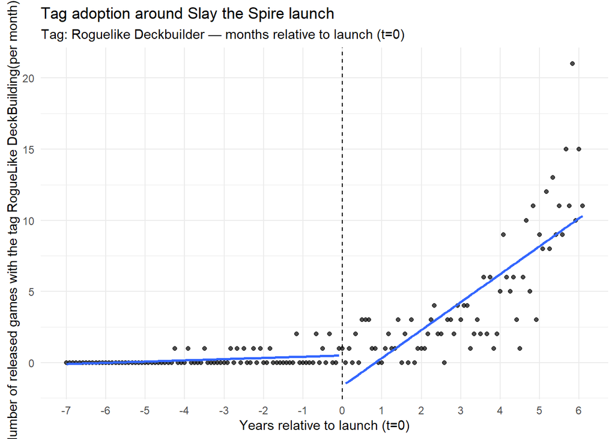

```
## [1] TRUE
```

```
##
## Call:
## lm(formula = freq ~ t + post + t:post, data = ts_slayTheSpire)
##
## Residuals:
##     Min      1Q  Median      3Q     Max
## -6.2087 -0.4368 -0.1021  0.5213 11.1710
##
## Coefficients:
##              Estimate Std. Error t value Pr(>|t|)
## (Intercept)  0.529412   0.403337   1.313 0.191278
## t            0.007563   0.008292   0.912 0.363151
## post        -2.164115   0.599569  -3.609 0.000414 ***
## t:post       0.156203   0.013316  11.731  < 2e-16 ***
## ---
## Signif. codes:  0 '***' 0.001 '**' 0.01 '*' 0.05 '.' 0.1 ' ' 1
##
## Residual standard error: 1.876 on 154 degrees of freedom
## Multiple R-squared:  0.7433, Adjusted R-squared:  0.7383
## F-statistic: 148.7 on 3 and 154 DF,  p-value: < 2.2e-16
```

```
##
## Call:
## lm(formula = freq ~ t + post + t:post, data = ts_global)
##
## Residuals:
##     Min      1Q  Median      3Q     Max
## -427.10  -66.85   -1.87   81.84  474.64
##
## Coefficients:
##              Estimate Std. Error t value Pr(>|t|)
## (Intercept)  630.1863    28.6368  22.006  < 2e-16 ***
## t              8.6137     0.5887  14.631  < 2e-16 ***
## post        -291.8553    42.5691  -6.856 1.61e-10 ***
## t:post         6.3578     0.9454   6.725 3.24e-10 ***
## ---
## Signif. codes:  0 '***' 0.001 '**' 0.01 '*' 0.05 '.' 0.1 ' ' 1
##
## Residual standard error: 133.2 on 154 degrees of freedom
## Multiple R-squared:  0.9061, Adjusted R-squared:  0.9042
## F-statistic: 495.2 on 3 and 154 DF,  p-value: < 2.2e-16
```

[figure not shown]

```
##
## Call:
## lm(formula = freq ~ t * post * series, data = combined)
##
## Residuals:
##     Min      1Q  Median      3Q     Max
## -427.10   -4.05   -0.12    4.33  474.64
##
## Coefficients:
##                   Estimate Std. Error t value Pr(>|t|)
## (Intercept)       630.1863    20.2513  31.118  < 2e-16 ***
## t                   8.6137     0.4163  20.689  < 2e-16 ***
## post             -291.8553    30.1039  -9.695  < 2e-16 ***
## seriestag        -629.6569    28.6396 -21.986  < 2e-16 ***
## t:post              6.3578     0.6686   9.509  < 2e-16 ***
## t:seriestag        -8.6061     0.5888 -14.617  < 2e-16 ***
## post:seriestag    289.6912    42.5733   6.805 5.29e-11 ***
## t:post:seriestag   -6.2015     0.9455  -6.559 2.29e-10 ***
## ---
## Signif. codes:  0 '***' 0.001 '**' 0.01 '*' 0.05 '.' 0.1 ' ' 1
##
## Residual standard error: 94.18 on 308 degrees of freedom
## Multiple R-squared:  0.9488, Adjusted R-squared:  0.9476
## F-statistic: 815.6 on 7 and 308 DF,  p-value: < 2.2e-16
```

## Game Study: The Binding Of Isaac + The Binding Of Isaac Rebirth (Roguelike)

```
## [1] "The Binding of Isaac"
```

```
## [1] "2011-09-28"
```

```
## [1] "The Binding of Isaac: Rebirth"
```

```
## [1] "2014-11-04"
```

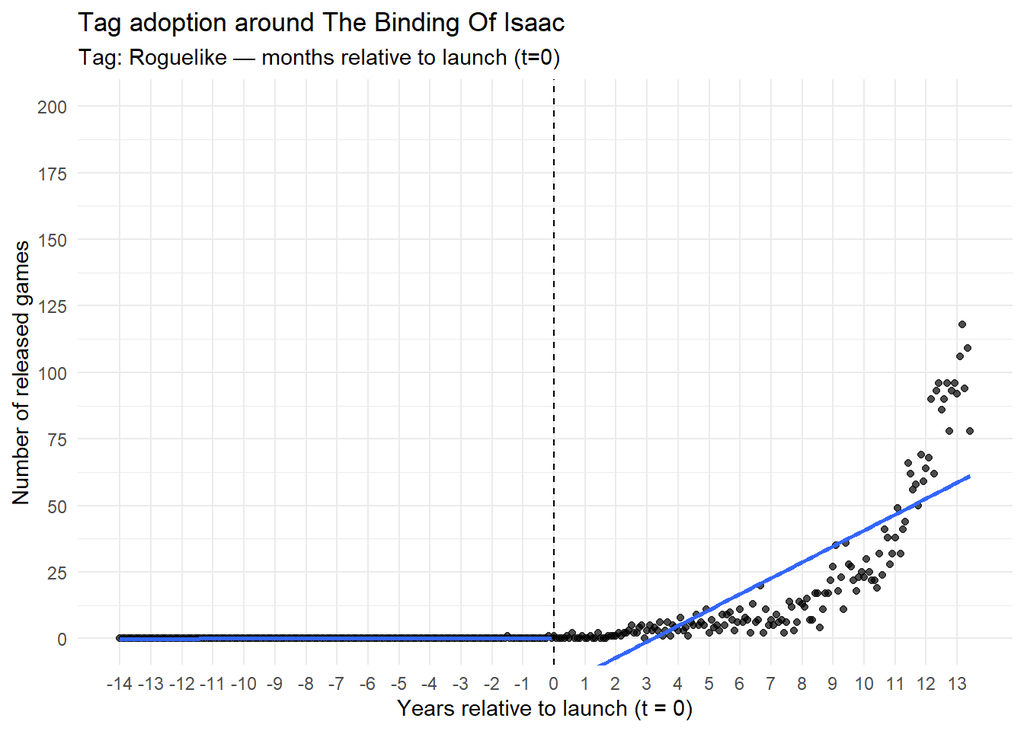

```
## [1] TRUE
```

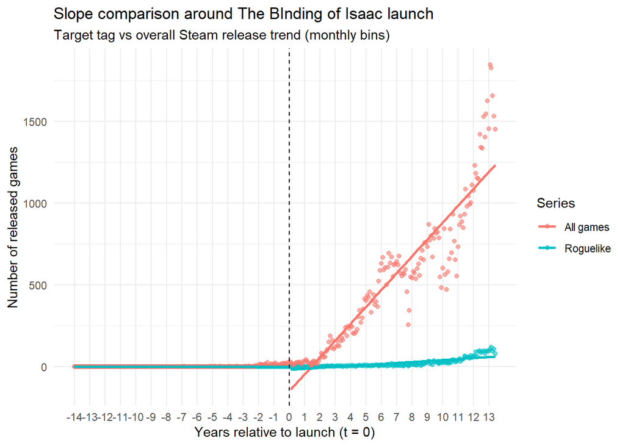

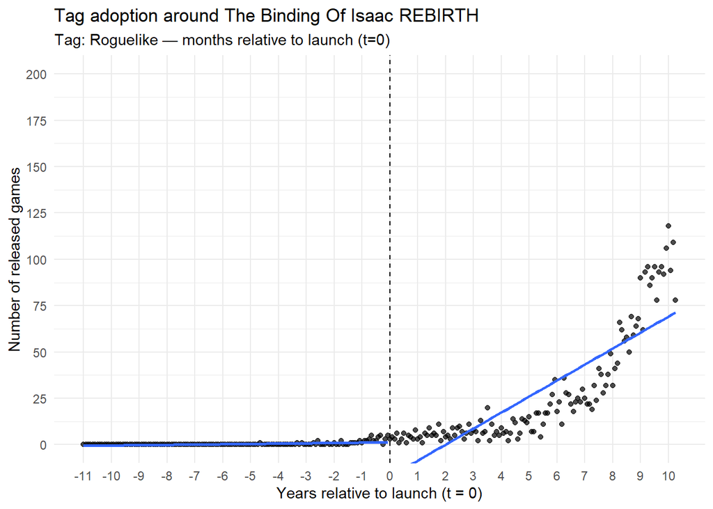

```
## [1] TRUE
```

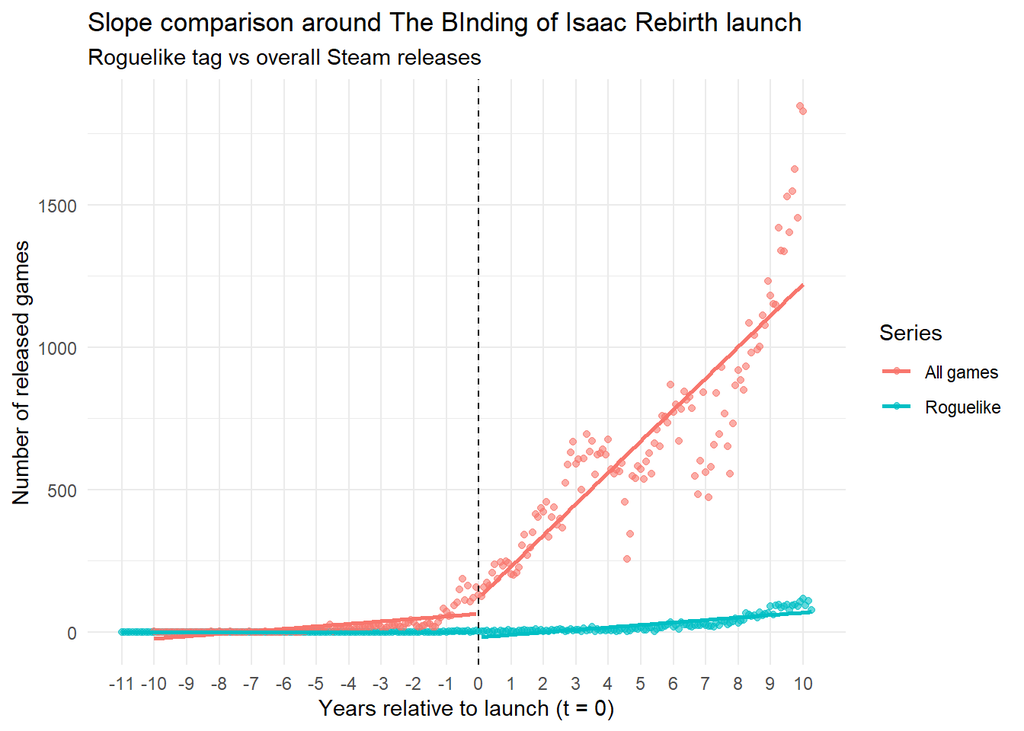

```
## [1] "Terraria"
```

```
## [1] "2011-05-16"
```

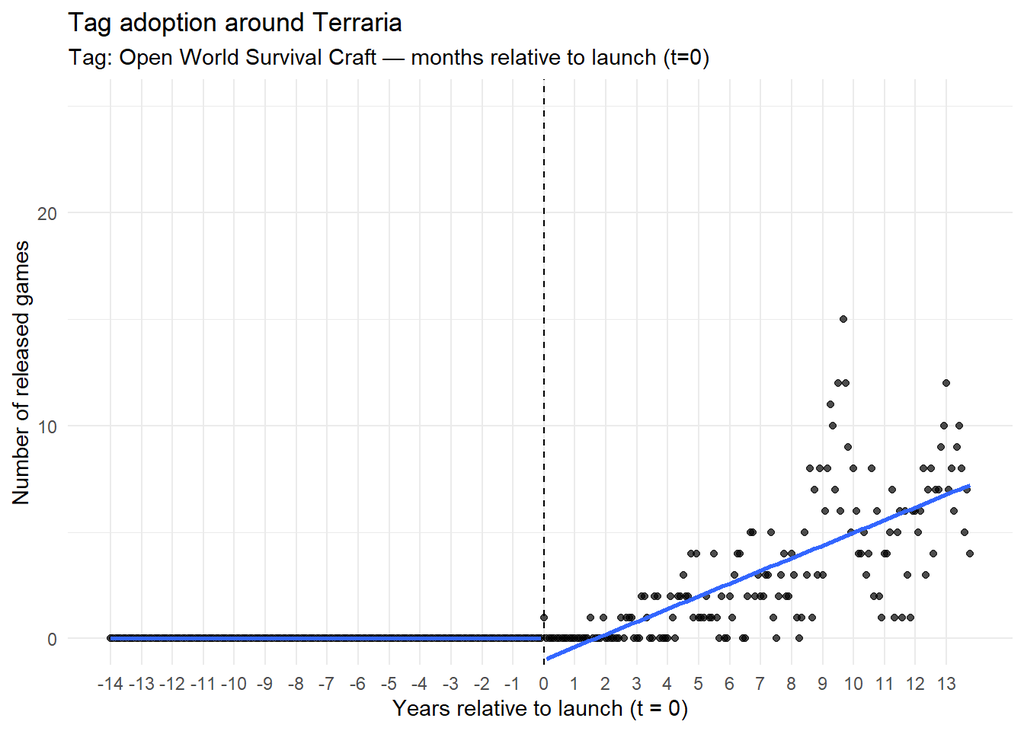

```
## [1] TRUE
```

## Game Study: Among Us (Social Deduction)

```
## [1] "Among Us"
```

```
## [1] "2018-11-16"
```

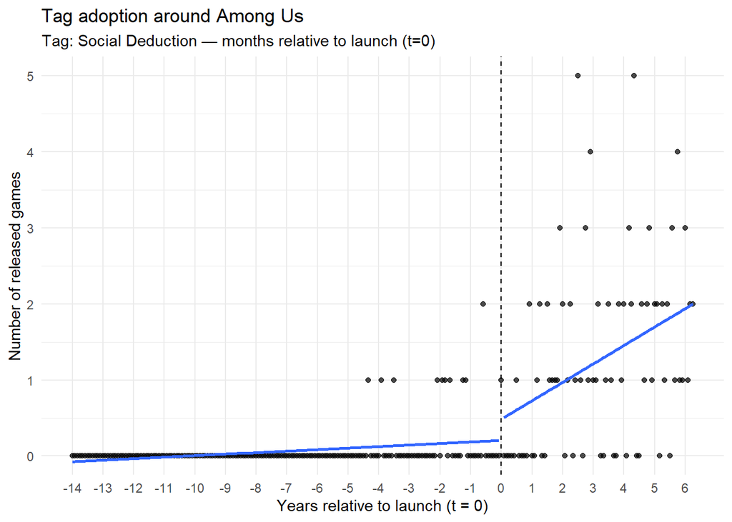